# Report

Author

Miguel Angel Donado Fernandez

Published

June 20, 2026

**RQ2:** Analyze whether the learning rate parameter affects the convergence speed of the BM model without significantly altering the final ability of the system to approach a DUE state.

Convergence is measured via three R-gap variants computed by the `DUE_convergence` package: aggregated R-gap (overall convergence level), refined R-gap by departure interval (temporal heterogeneity), and OD-specific R-gap (spatial heterogeneity). BM is compared against `duaIterate` — SUMO’s built-in DUE solver — as a sanity-check baseline.

On this research question only the aggregated R-gap will be considered.

**The plots to answer this question will be:**

1. Aggregated R-gap for different learning rates across episodes (representative learning dynamics)
2. Sensitivity analysis
3. Convergence episode vs Learning rate
4. (Appendix) Policy stabilization

For more details, check the research questions document.

```r
# To make sure r virtual environment is loaded when executing this script from python
library(renv)
renv::load()
```

```
- The project is out-of-sync -- use `renv::status()` for details.
```

```r
library(tidyverse)
library(arrow)
library(ggh4x)
```

```r
library(here)

# Load custom theme
source(file = here("r","shared","theme.R"))

# Make it global theme (every plot automatically uses it)
theme_set(theme_thesis())

# Builds the congestion_regime factor from whatever n_agents values are
# present in the data, instead of hardcoding levels/labels per plot.
# congestion_regime_tiers <- c("Near free-flow", "Moderate", "High")
congestion_regime_tiers <- c("Near free-flow", "Moderate", "High")

make_congestion_regime <- function(n_agents) {
  levels_sorted <- sort(unique(n_agents))

  if (length(congestion_regime_tiers) != length(levels_sorted)) {
    stop("The number of congestion regime tiers must equal the number of unique agent counts.")
  }

  factor(
    n_agents,
    levels = levels_sorted,
    labels = paste0(congestion_regime_tiers, " (", levels_sorted, ")"))
}
```

```r
# This function helps us to create reliable file paths
data_dir <- here("r","RQ3","data")

# Dynamic data import
# 1) list.files(): returns a vector with the file paths
# 2) set_names(): transforms it into a named vector, with names equal to the filename without extension. This functions are vectorized, thats why it works
# 3) map(): maps the function to every parquet file. It returns a list, where each element is a df
data <- list.files(data_dir, pattern="\\.parquet$", full.names = TRUE) |>
  (\(x) set_names(x, tools::file_path_sans_ext(basename(x))))() |>
  map(read_parquet)
```

```r
# Randomly select 3 seeds (seeded so the same 3 - and their colors - are
# picked every time this re-renders)
set.seed(123)
representative_seeds <- sample(unique(data$bm_rgap$seed), size = 3)

labels_seeds <- c("S1", "S2", "S3")

color_lines <- c(
  "0.9" = "#0072B2",  # blue
  "0.6" = "#E69F00",  # orange
  "0.2" = "#009E73"  # bluish green
)
```

```r
representative_learning_rate_levels <- c("0.9","0.6","0.2")
representative_learning_rate_labels <- map_chr(representative_learning_rate_levels, \(x) paste0("l = ", x))

# Not aggregating mean +/- SD across seeds here: seeds finish training at very
# different episode counts (e.g. High regime: some stop by episode ~22, one
# runs to 129), so for a large share of each panel's episode range the "mean"
# would silently collapse to a single seed's raw value (SD undefined). Each
# seed's own trajectory is plotted instead - no cross-seed averaging, so no
# misleading shrinking-N problem.

rgap_df <- data$bm_rgap |>
  mutate(
    congestion_regime = make_congestion_regime(n_agents),
    ) |>
  filter(
    seed %in% representative_seeds
  ) |>
  mutate(
    seed_fct = factor(seed, levels = representative_seeds, labels = labels_seeds)
  ) |>
  filter(
    learning_rate %in% representative_learning_rate_levels
  ) |>
  mutate(
    learning_rate_fct = factor(learning_rate, levels = representative_learning_rate_levels, labels = representative_learning_rate_labels)
  ) |>
  mutate(learning_rate_fct = fct_rev(learning_rate_fct))
```

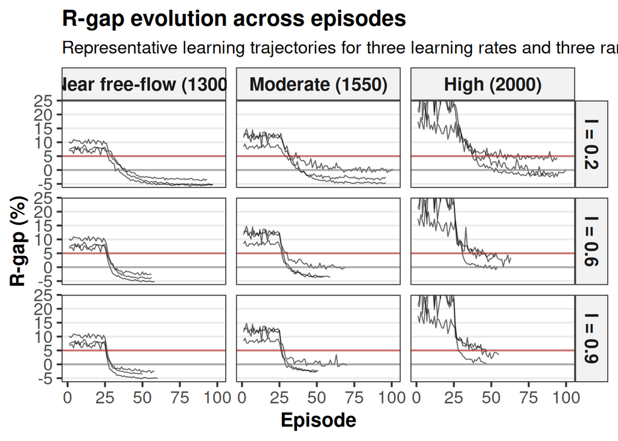

```r
upper_limit_y_axis <- quantile(rgap_df$rgap, probs = c(0.95))

ggplot(
  data = rgap_df,
  mapping = aes(x = episode, y = rgap, group = seed_fct)
) +
  geom_line(alpha = 0.6, linewidth = 0.4) +
  geom_hline(yintercept = 0, alpha = 0.6, linewidth = 0.7, color = "#7D7D7D") +
  geom_hline(yintercept = 5, alpha = 0.6, linewidth = 0.7, color = "#B22222") +
  facet_grid(learning_rate_fct ~ congestion_regime) +
  labs(
    title = "R-gap evolution across episodes",
    subtitle = "Representative learning trajectories for three learning rates and three random seeds (BM)",
    x = "Episode",
    y = "R-gap (%)"
  ) +
coord_cartesian(ylim=c(-5,upper_limit_y_axis))
```

```r
ggsave(here("r","RQ3","figures","plot1_rgap_evolution_l_seed.png"), width = 12, height = 6)
```

## Interpretation plot 1:

```r
sensitivity_df <- data$bm_rgap |>
  mutate(
    learning_rate = as.numeric(learning_rate),
    congestion_regime = make_congestion_regime(n_agents),
  ) |>
  select(-c(n_agents)) |>
  group_by(seed, congestion_regime, learning_rate) |>
  slice_max(episode, n = 1) |>
  ungroup()

sensitivity_df_summary <- sensitivity_df |>
  group_by(learning_rate, congestion_regime) |>
  summarise(
    median_rgap = median(rgap)
  ) |>
  ungroup()
```

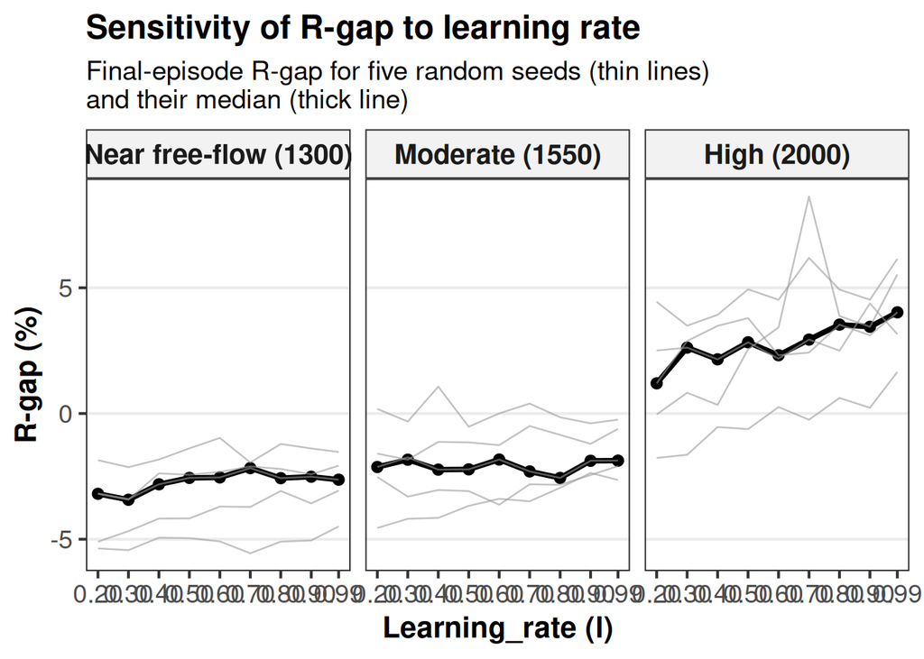

```r
ggplot(
  data = sensitivity_df_summary,
  mapping = aes(
    x = learning_rate,
    y = median_rgap
  )
) +
  geom_point() +
  geom_line(linewidth=1.4) +
  geom_line(
    data = sensitivity_df,
    mapping = aes(
      x = learning_rate,
      y = rgap,
      group = seed
    ),
    linewidth = 0.45,
    alpha = 0.6,
    colour = "grey60"
  ) +
  facet_wrap(~congestion_regime) +
  labs(
    title = "Sensitivity of R-gap to learning rate",
    subtitle = "Final-episode R-gap for five random seeds (thin lines) \nand their median (thick line)",
    x = "Learning_rate (l)",
    y = "R-gap (%)"
  ) +
  scale_x_continuous(
    breaks = unique(sensitivity_df$learning_rate)
  )
```

```r
ggsave(here("r","RQ3","figures","plot2_sensitivity_analysis_learning.png"), width = 12, height = 6)
```

```r
rgap_threshold <- 5

convergence_speed_df <- data$bm_rgap |>
  mutate(
    learning_rate = as.numeric(learning_rate),
    congestion_regime = make_congestion_regime(n_agents),
  ) |>
  select(-c(n_agents)) |>
  mutate(
    below = rgap < rgap_threshold
  ) |>
  group_by(seed, learning_rate, congestion_regime) |>
  # TRUE if all remaining episodes are below threshold
  mutate(
    remainder = map_lgl(
      # Returns a vector with all the row numbers
      row_number(),
      \(x) all(below[x:n()])
      )
  ) |>
  filter(remainder) |>
  slice_head(n = 1) |>
  rename(
    convergence_episode = episode
  ) |>
  ungroup() |>
  select(-c(below, remainder))

convergence_speed_df_summary <- convergence_speed_df |>
  group_by(learning_rate, congestion_regime) |>
  summarise(
    median_convergence_episode = median(convergence_episode)
  ) |>
  ungroup()
```

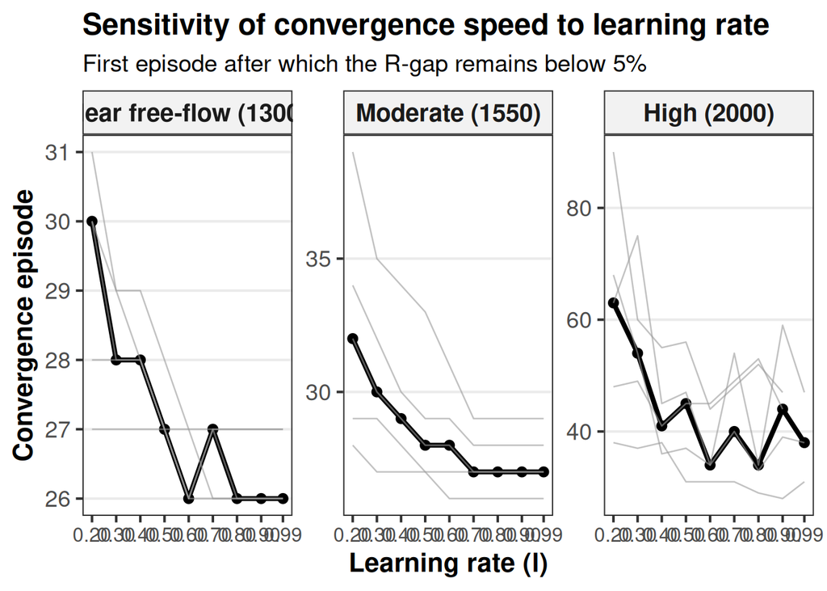

```r
ggplot(
  data = convergence_speed_df_summary,
  mapping = aes(
    x = learning_rate,
    y = median_convergence_episode
  )
) +
  geom_point() +
  geom_line(linewidth=1.4) +
  geom_line(
    data = convergence_speed_df,
    mapping = aes(
      x = learning_rate,
      y = convergence_episode,
      group = seed
    ),
    linewidth = 0.45,
    alpha = 0.6,
    colour = "grey60"
  ) +
  facet_wrap(~congestion_regime, scales = "free_y") +
  labs(
    title = "Sensitivity of convergence speed to learning rate",
    subtitle = paste0("First episode after which the R-gap remains below ", rgap_threshold, "%"),
    x = "Learning rate (l)",
    y = "Convergence episode"
  ) +
  scale_x_continuous(
    breaks = unique(convergence_speed_df$learning_rate)
  ) +
  theme(
    axis.text.x = element_text(size = 12)
  )
```

```r
ggsave(here("r","RQ3","figures","plot3_convergence_speed_l.png"), width = 12, height = 6)
```

## Interpretation plot 3

- **Convergence speed (DUE)**:
  - Higher learning rates generally reduce the convergence episode.
  - The benefit of increasing the learning rate becomes more pronounced as the network becomes more congested. The improvement is much more substantial in the high congestion case (roughly 63 - 35/40)
  - Most of the gain seems to occur between 0.2 and 0.6. Beyond that, increasing the learning rate further produces relatively small additional reductions in convergence speed.
- **Robustness across seeds**: All seeds show similar behavior.

```r
plot4_learning_rate_levels <- c("0.2", "0.4", "0.6", "0.8", "0.99")

# Single representative seed (reusing the first of plot1's representative_seeds)
# instead of averaging across seeds - seeds finish training at different episode
# counts, so a cross-seed mean would shrink in N towards the tail of each panel.
plot4_seed <- representative_seeds[1]

policy_change_df <- data$bm_policy_change |>
  mutate(
    learning_rate = as.numeric(learning_rate),
    congestion_regime = make_congestion_regime(n_agents),
  ) |>
  select(-c(n_agents)) |>
  filter(
    seed == plot4_seed,
    as.character(learning_rate) %in% plot4_learning_rate_levels
  )
```

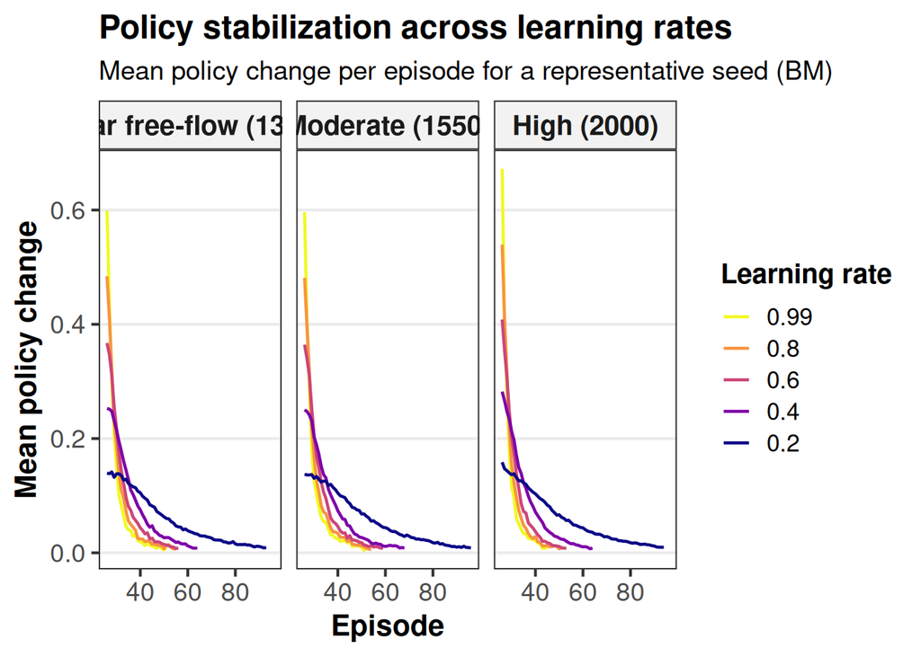

```r
ggplot(
  data = policy_change_df,
  mapping = aes(
    x = episode,
    y = mean_policy_change,
    color = fct_rev(factor(learning_rate))
  )
) +
  geom_line(linewidth = 0.8) +
  facet_wrap(~congestion_regime) +
  scale_color_viridis_d(
      option = "plasma",
      direction = -1,
      name = "Learning rate"
  ) +
  labs(
    title = "Policy stabilization across learning rates",
    subtitle = "Mean policy change per episode for a representative seed (BM)",
    x = "Episode",
    y = "Mean policy change"
  )
```

```r
ggsave(here("r","RQ3","figures","plot4_policy_stabilization_learning_rate.png"), width = 12, height = 6)
```

## Interpretation plot 4

- It shows that increasing the learning rate results in larger initial policy adjustments but also earlier stabilization of agents policies.